# Google Play Store Download Analysis by Raphael Trench

# Univariate Plots Section

## Category

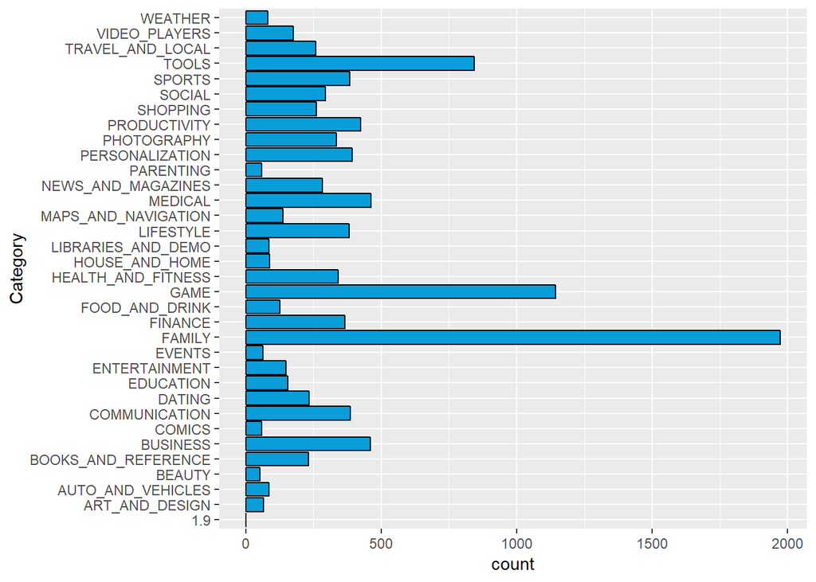

It seems that most apps fall under the categories ‘Family’,‘Game’ or ‘Tools’.

Lastly, it seems there is a single app in the category named ‘1.9’, which seems to be a mistake. Because of that this app will be not be included in the analysis from now on.

## Rating

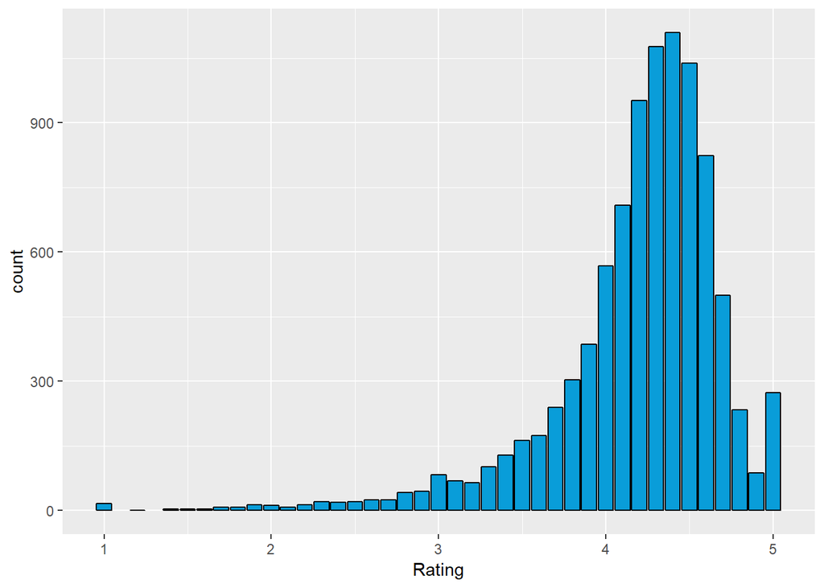

```
##    Min. 1st Qu.  Median    Mean 3rd Qu.    Max.    NA's
##   1.000   4.000   4.300   4.192   4.500   5.000    1474
```

Interestingly, the previously removed app from the ‘1.9’ category had a rating of 19 stars, which is obviously wrong, since the maximum is 5. This confirms that this specific observation was garbage data and would corrupt the analysis.

## Reviews

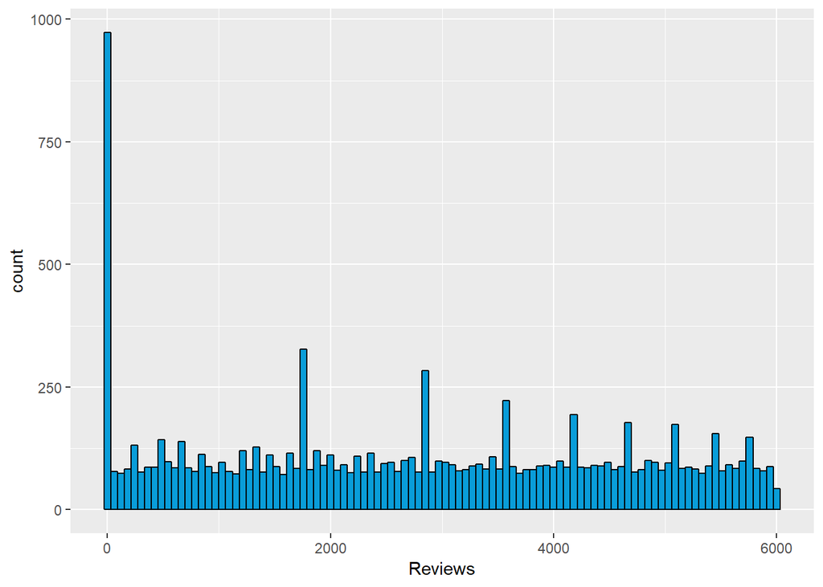

```
##    Min. 1st Qu.  Median    Mean 3rd Qu.    Max.
##       1    1157    2747    2744    4320    6002
```

The maximum amount of reviews is 6002 and the mean is 2744, which is close to the median of 2747.

## Size

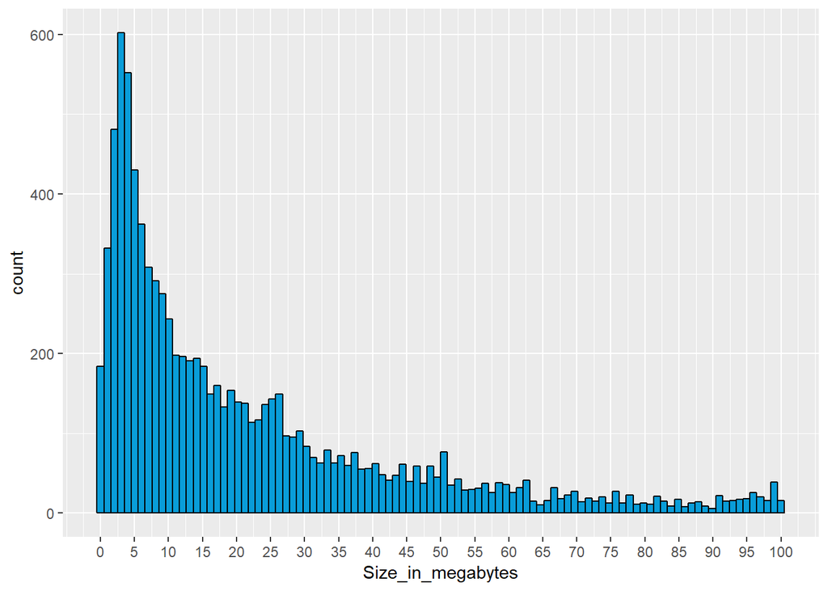

```
##     Min.  1st Qu.   Median     Mean  3rd Qu.     Max.     NA's
##   0.0085   4.9000  13.0000  21.5165  30.0000 100.0000     1695
```

```
## Number of Apps with device depandent size: 14
```

The plot above shows that most of the apps are on the lighter side, with the majority having less than 15Mb in size.

Some app size’s are device dependant, but they are very few in number.

## Installs

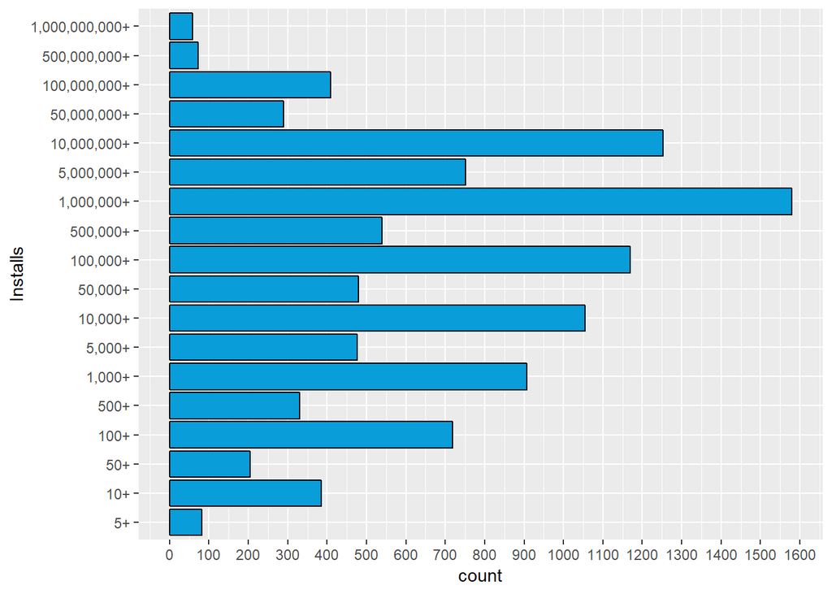

The distribution for installations doesnt’t seem to follow any particular trend, as the range of number of apps for each category of Installs varies a great deal.

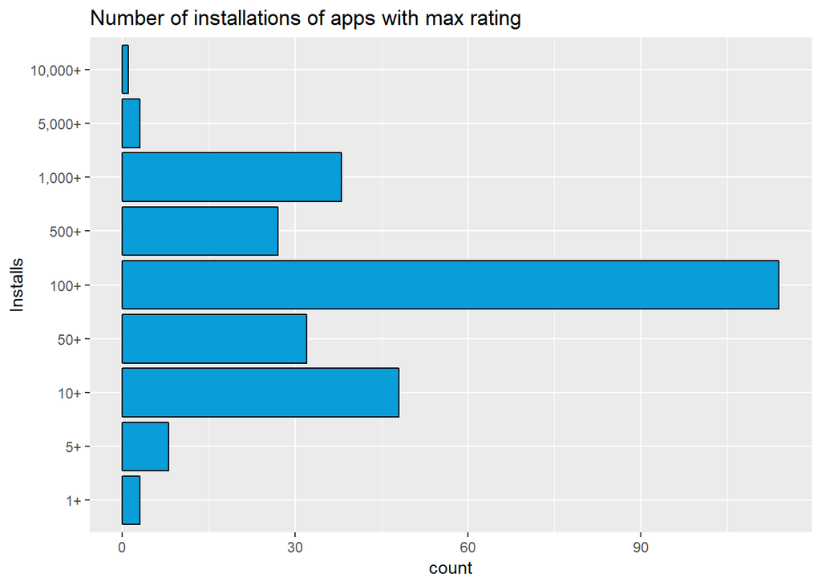

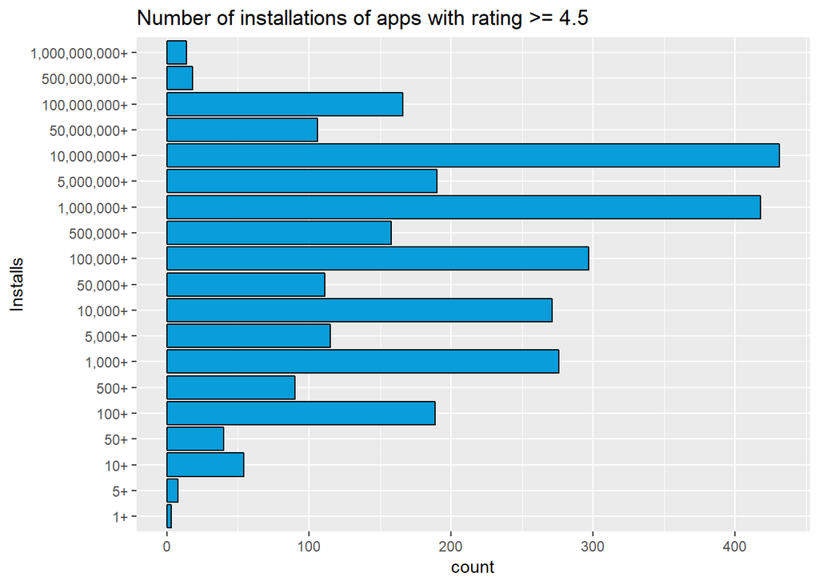

Are apps with great ratings downloaded more?

The first plot not only shows that there are few apps with a perfect rating of 5, but also that those apps dont have a great number of installations.

One could consider the possibility that these apps are newer, and because of that dont have a great number of downloads. Not only that, but since the rating is actually a mean of ratings, if a single person voted for a rating below 5, the rating would decrease. The more people that do download the app, the greater the odds are that this could happen.

Though more apps are considered in this plot, as opposed to what one could believe, having a good rating does not necessarily mean the app will be within the most downloaded, as the number of apps for every category still varies a lot.

## Type

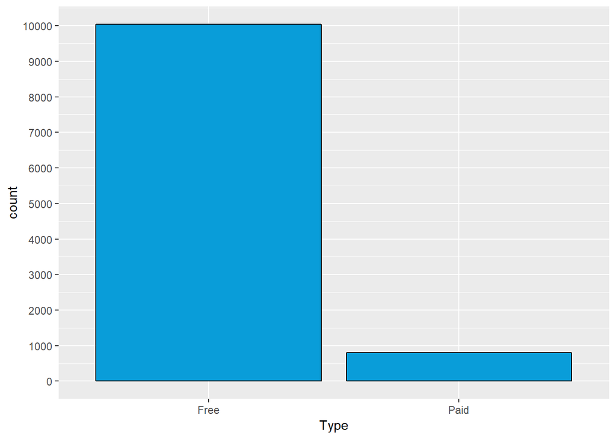

The plot above demonstrates that at least in this dataset, the number of free apps is overwhelmingly bigger than the number of paid apps.

This raises an interesting question: are paid apps less downloaded than free ones? This question will be more throughly explored in the bivariate section.

## Price

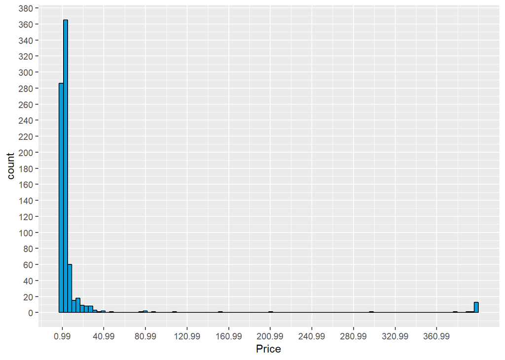

```
##    Min. 1st Qu.  Median    Mean 3rd Qu.    Max.
##    0.99    1.49    2.99   13.92    4.99  400.00
```

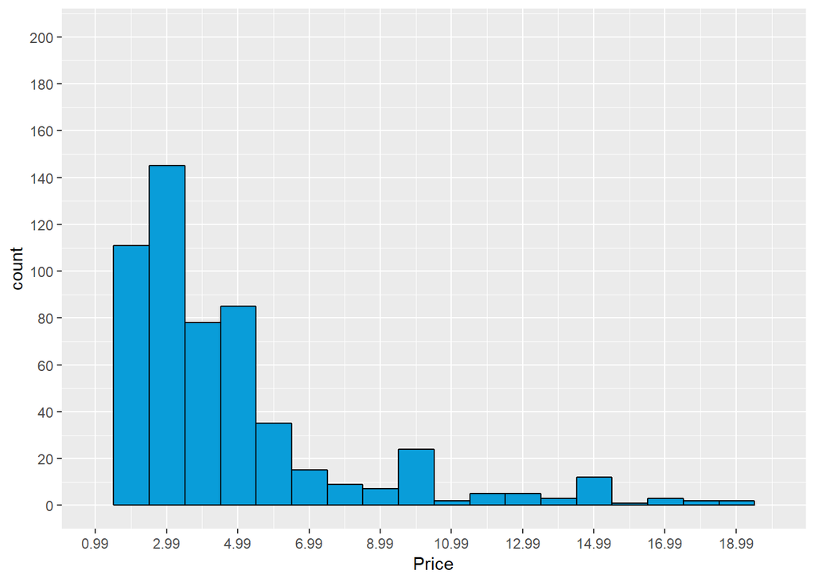

```
##    Min. 1st Qu.  Median    Mean 3rd Qu.    Max.
##   0.990   1.490   2.990   3.955   4.990  19.990
```

Curiously there are some apps that are priced 400 dollars, which is most likely a mistake. There is also a very small number of apps which are priced over 20 dollars.

On the second histogram, only apps which have a price of 20 or less dollars are plotted, which seems to be the range of where most apps are in.

## Content Rating

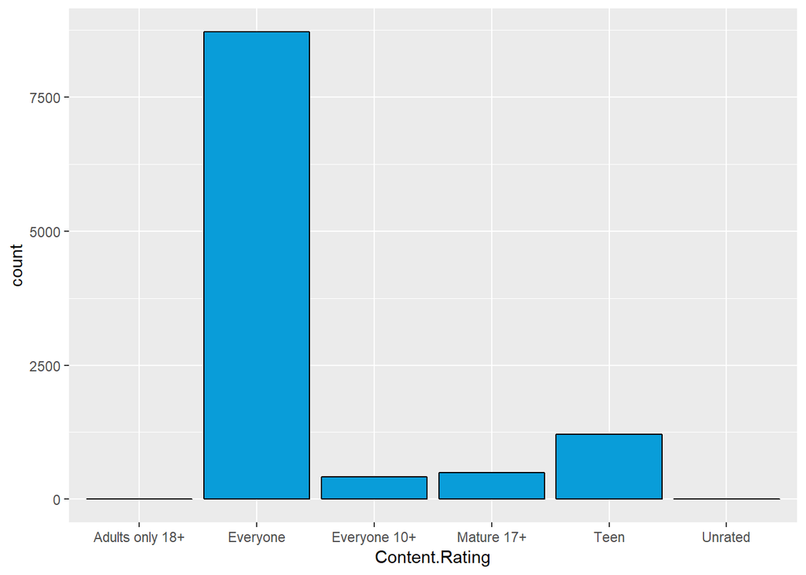

The majority of apps are rated for Everyone, by a huge difference.

Of the age specific categories, most apps are rated for teens, and very few are for adults.

## Android Version

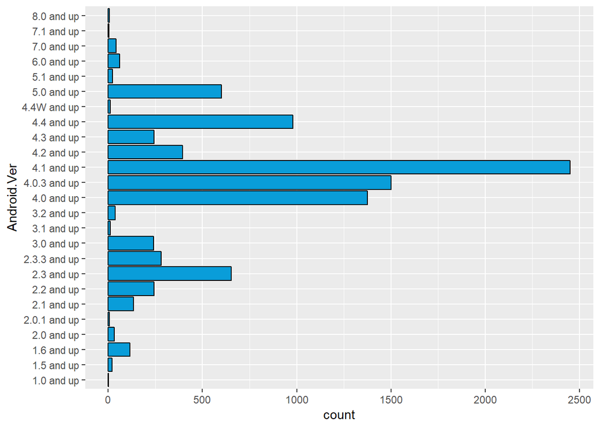

Excluding the apps for which the minimum Android version varies with the device, there are very few apps which require a version above 5.0, and similarly, below 2.1.

With that in mind, most apps have a minimum required Android version ranging from 4.0 to 4.1.

It is possible to infer some information from this: most apps could be in the ‘middle’ range of versions because there are less users with older phones and very new phones as well.

## Genres

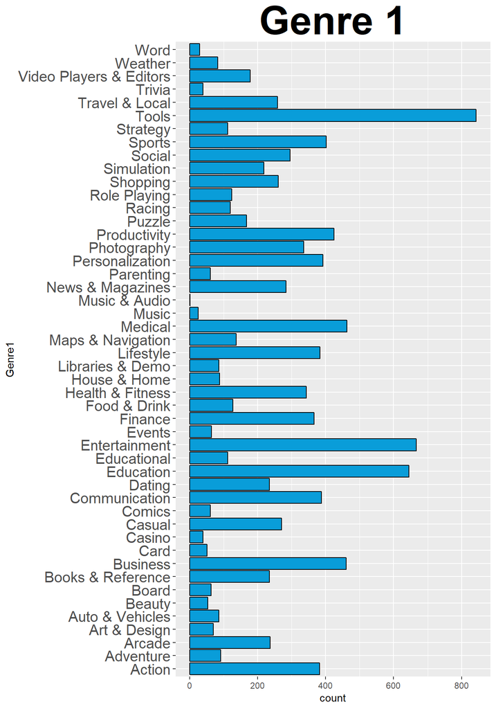

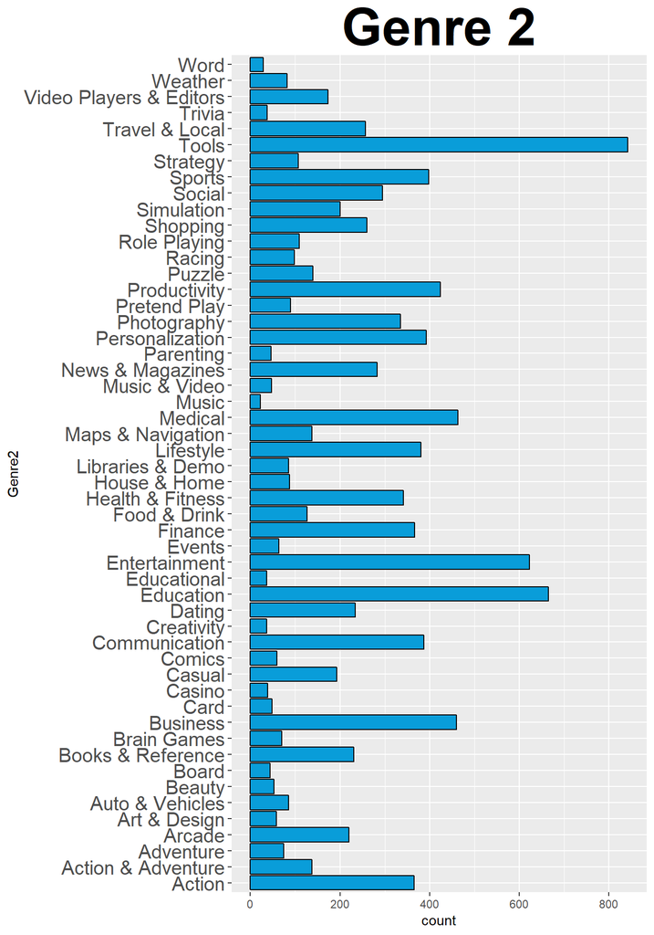

Each app in the dataset has up to 2 Genres. To make visualization and analysis on this variable simpler and easier, I have separeted it into 2 variables, Genre1 and Genre2.

Both genres seem to follow similar distributions, with the categories ‘tools’,‘entertainment’,‘education’,‘medical’ and ‘business’ possessing the most apps.

### Other Variables

The variables Current.Ver and Last.Updated will not be analysed due to their great number of unique values and lack of relevance.

# Univariate Analysis

### What is the structure of your dataset?

The dataset consists of 10841 observations and 13 variables.

The variables Category,Type,Installs,Content.Rating,Genres and Android.Ver are categorical.

Some notable observations: - Most apps require a minimum Android Version between 4.0 and 4.1 - There doesn’t seem to be a linear trend between rating and number of installations - Most apps have a high rating, with the mean rating being 4.192 and its median being 4.3. - The majority of apps is free to download.

### What is/are the main feature(s) of interest in your dataset?

The main feature of interest is Installs, which is how many people have downloaded the app.

Though there are way more factors that can impact how famous an app is (such as marketing campaigns for example), I would like to explore if there is a trend between the most downloaded apps.

### What other features in the dataset do you think will help support your investigation into your feature(s) of interest?

I believe that features such as Price, Category and Genres can probably help find the trend im looking for.

Another feature that may help on estabilishing if an app is popular is the number of Reviews it has.

### Did you create any new variables from existing variables in the dataset?

I did create new variables, tho they do not really express any new information, as they were created with the purpose normalizing or cleaning data,to make analysis possible.

These variables are: -Genres1 and Genres2, which were created as the variable Genres had combinations of up to 2 differente genres, which would make visualisation hard. -Size_in_Megabytes, as the original variable Size was not numeric, I had to remove the letters which indicated data size (M for Megabytes for example) and convert all sizes to Megabytes.

### Of the features you investigated, were there any unusual distributions? Did you perform any operations on the data to tidy, adjust, or change the form of the data? If so, why did you do this?

I don’t believe that there were any unusual distributions.

As mentioned above, I had to make some operations to tidy and adjust data. Alongside the previously mentioned new variables, I also modified the variable Price, as it was not numeric before and I had to remove the ‘$’ symbol.

I performed these operations to make analysis of these variables simpler,easier and most important, possible.

# Bivariate Plots Section

## Relationships of Installs with other variables

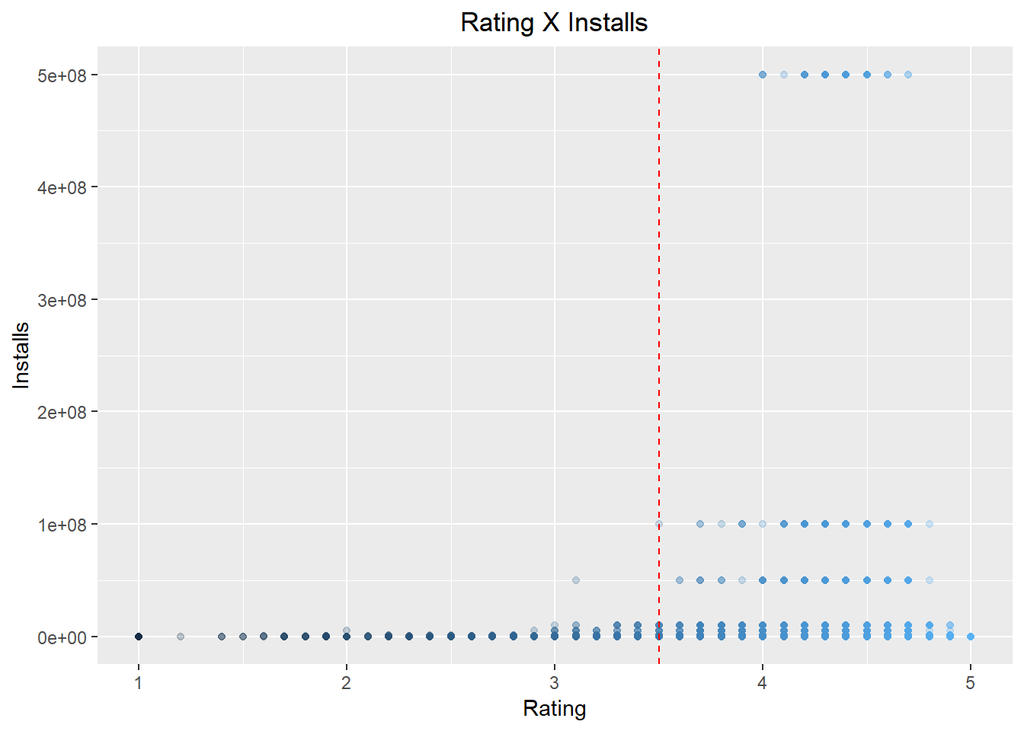

Just like in the previous analysis of Installs, it is possible to observe that having a high rating will not imply in having a great number of installations. However now that both variables are being analysed against eachother, one can clearly see that of the most downloaded apps, almost all of them have a rating of at least around 3.5.

Lastly, of the most downloaded apps overall, all of them have a minimum rating around 4.

To sum up, though not all apps with a good rating are between the most downloaded, all apps between the most downloaded have good ratings.

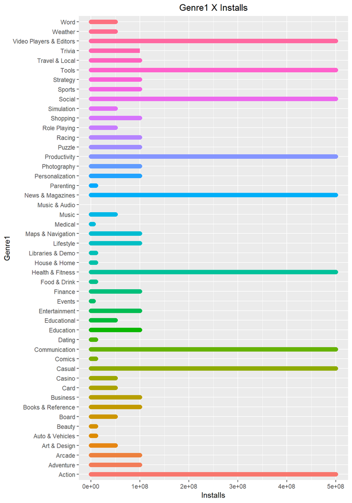

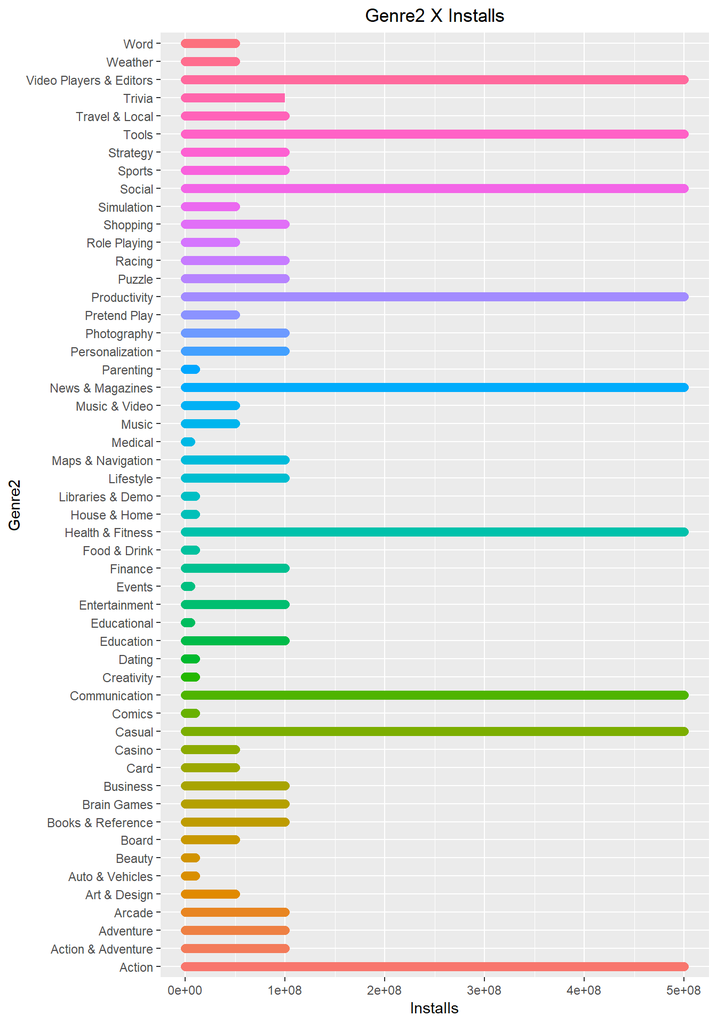

With these plots, it becomes way more intuitive to see just which genres the most downloaded apps have, as the variance between the few and most installed is apparent.

The most famous genres in the app store are: Video Players and Editors, Action, Casual, Communication, Health and Fitness, News and Magazines, Productivity, Social and Tools.

It is very insightful to learn how much famous some genres are in comparison to most, as with this kind of knowledge it is possible to begin determining the overall trend of the most downloaded apps.

Lastly, since both genres seem to not show much difference between plots, to avoid further visual pollution, from now on I will only take into account the first genre, as not all apps possess a second one.

```
## df$Genre1: Action
##      Min.   1st Qu.    Median      Mean   3rd Qu.      Max.
##        10    100000   5000000  24686020  10000000 500000000
## --------------------------------------------------------
## df$Genre1: Adventure
##      Min.   1st Qu.    Median      Mean   3rd Qu.      Max.
##        10     50000    500000  14647751  10000000 100000000
## --------------------------------------------------------
## df$Genre1: Arcade
##      Min.   1st Qu.    Median      Mean   3rd Qu.      Max.      NA's
##         1    100000   1000000  20750386  10000000 100000000         6
## --------------------------------------------------------
## df$Genre1: Art & Design
##     Min.  1st Qu.   Median     Mean  3rd Qu.     Max.
##        0    10000   100000  1825190   500000 50000000
## --------------------------------------------------------
## df$Genre1: Auto & Vehicles
##     Min.  1st Qu.   Median     Mean  3rd Qu.     Max.
##        1     1000   100000   625061   500000 10000000
## --------------------------------------------------------
## df$Genre1: Beauty
##     Min.  1st Qu.   Median     Mean  3rd Qu.     Max.
##       50    10000    50000   513152   500000 10000000
## --------------------------------------------------------
## df$Genre1: Board
##     Min.  1st Qu.   Median     Mean  3rd Qu.     Max.
##       10     5000   100000  2873245  1000000 50000000
## --------------------------------------------------------
## df$Genre1: Books & Reference
##      Min.   1st Qu.    Median      Mean   3rd Qu.      Max.      NA's
##         1      1000     10000   3954853   1000000 100000000         1
## --------------------------------------------------------
## df$Genre1: Business
##      Min.   1st Qu.    Median      Mean   3rd Qu.      Max.
##         0       100      1000   2178076    100000 100000000
## --------------------------------------------------------
## df$Genre1: Card
##     Min.  1st Qu.   Median     Mean  3rd Qu.     Max.
##      100    10000   100000  3410316  5000000 50000000
## --------------------------------------------------------
```

[output cut: 136 more lines]

```
## df$Genre1: Trivia
##      Min.   1st Qu.    Median      Mean   3rd Qu.      Max.
##        10      1000     10000   3297602    100000 100000000
## --------------------------------------------------------
## df$Genre1: Video Players & Editors
##      Min.   1st Qu.    Median      Mean   3rd Qu.      Max.      NA's
##        10     10000   1000000  18525730  10000000 500000000         3
## --------------------------------------------------------
## df$Genre1: Weather
##     Min.  1st Qu.   Median     Mean  3rd Qu.     Max.
##       10   100000  1000000  5196348  5000000 50000000
## --------------------------------------------------------
## df$Genre1: Word
##     Min.  1st Qu.   Median     Mean  3rd Qu.     Max.
##       50   100000  5000000  9281812 10000000 50000000
```

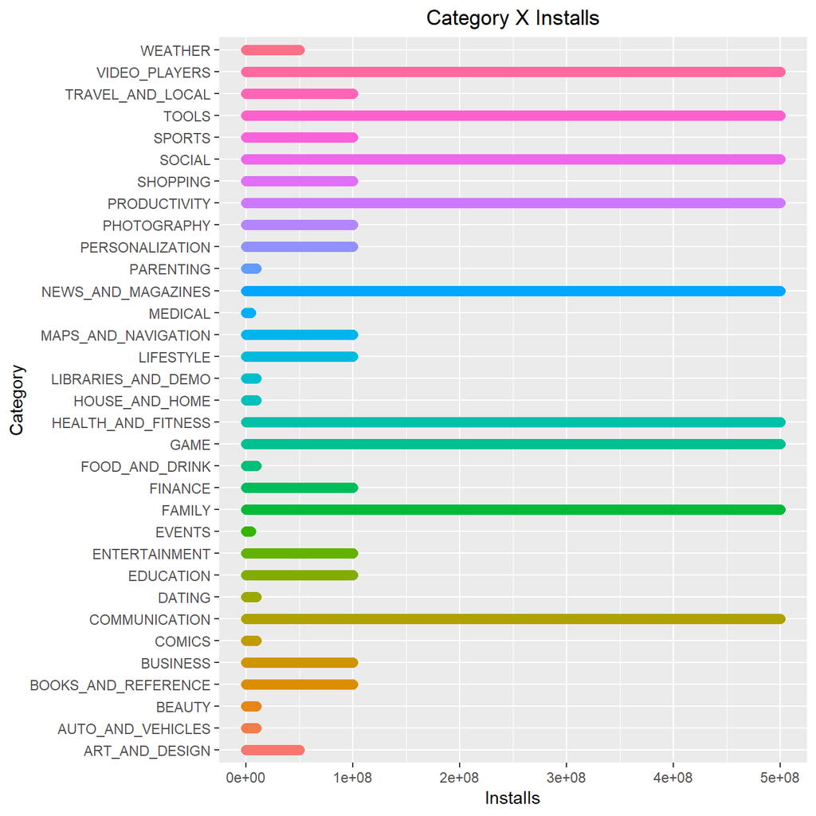

```
## df$Category: 1.9
## NULL
## --------------------------------------------------------
## df$Category: ART_AND_DESIGN
##     Min.  1st Qu.   Median     Mean  3rd Qu.     Max.
##        0    10000   100000  1912894   500000 50000000
## --------------------------------------------------------
## df$Category: AUTO_AND_VEHICLES
##     Min.  1st Qu.   Median     Mean  3rd Qu.     Max.
##        1     1000   100000   625061   500000 10000000
## --------------------------------------------------------
## df$Category: BEAUTY
##     Min.  1st Qu.   Median     Mean  3rd Qu.     Max.
##       50    10000    50000   513152   500000 10000000
## --------------------------------------------------------
## df$Category: BOOKS_AND_REFERENCE
##      Min.   1st Qu.    Median      Mean   3rd Qu.      Max.      NA's
##         1      1000     10000   4006389   1000000 100000000         1
## --------------------------------------------------------
## df$Category: BUSINESS
##      Min.   1st Qu.    Median      Mean   3rd Qu.      Max.
##         0       100      1000   2178076    100000 100000000
## --------------------------------------------------------
## df$Category: COMICS
##     Min.  1st Qu.   Median     Mean  3rd Qu.     Max.
##       50    10000   100000   934769  1000000 10000000
## --------------------------------------------------------
## df$Category: COMMUNICATION
##      Min.   1st Qu.    Median      Mean   3rd Qu.      Max.      NA's
##         1      1000   1000000  37084990  10000000 500000000        19
## --------------------------------------------------------
## df$Category: DATING
##     Min.  1st Qu.   Median     Mean  3rd Qu.     Max.
##        1     1000   100000  1129533   500000 10000000
## --------------------------------------------------------
## df$Category: EDUCATION
##      Min.   1st Qu.    Median      Mean   3rd Qu.      Max.
##      1000    500000   1000000   5586231   5000000 100000000
## --------------------------------------------------------
## df$Category: ENTERTAINMENT
```

[output cut: 79 more lines]

```
## df$Category: TOOLS
##      Min.   1st Qu.    Median      Mean   3rd Qu.      Max.      NA's
##         1      1000     50000  11239919   1000000 500000000         2
## --------------------------------------------------------
## df$Category: TRAVEL_AND_LOCAL
##      Min.   1st Qu.    Median      Mean   3rd Qu.      Max.      NA's
##         0     10000   1000000   7386906   5000000 100000000         5
## --------------------------------------------------------
## df$Category: VIDEO_PLAYERS
##      Min.   1st Qu.    Median      Mean   3rd Qu.      Max.      NA's
##        10     10000   1000000  18732574  10000000 500000000         3
## --------------------------------------------------------
## df$Category: WEATHER
##     Min.  1st Qu.   Median     Mean  3rd Qu.     Max.
##       10   100000  1000000  5196348  5000000 50000000
```

Fortunately, again it is possible to see noticeable difference between number of installations per category, which further helps identifying a trend.

Interestingly enough, some categories have the same name as a number of genres, mainly the ones that are most famous. This reinforces the idea that these genres/categories really are the ones in which consumers are the most interested in.

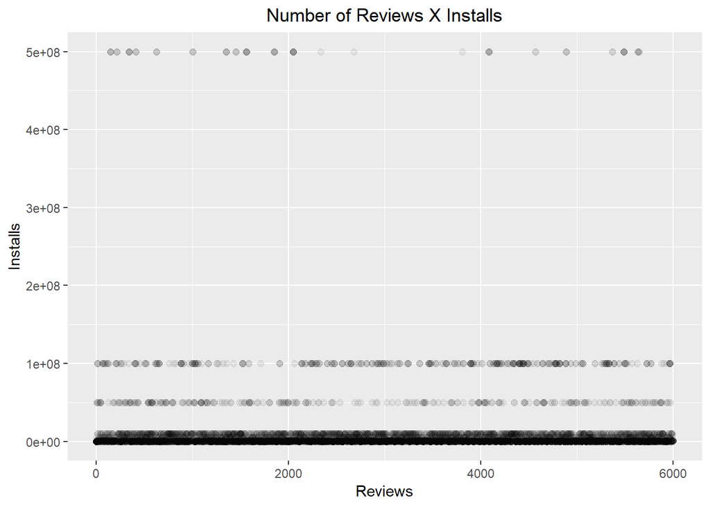

From this plot, it doesn’t seem like the number of reviews in an app is actually an important variable, as for all ‘categories’ of installations, the range of the number of reviews varies far too much.

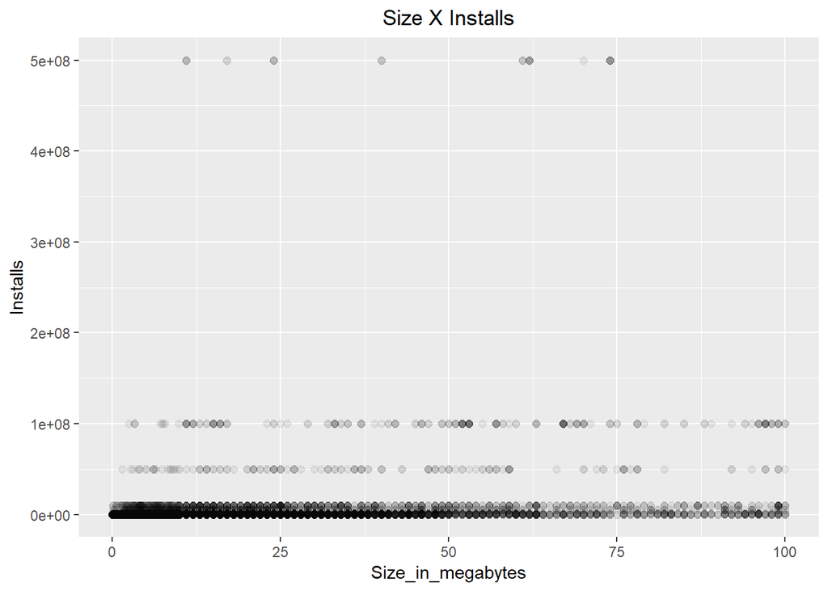

Just like in the previous plot, there isn’t much information to be gained from this one, as there is not really any range of size value that all or most of the most downloaded apps have.

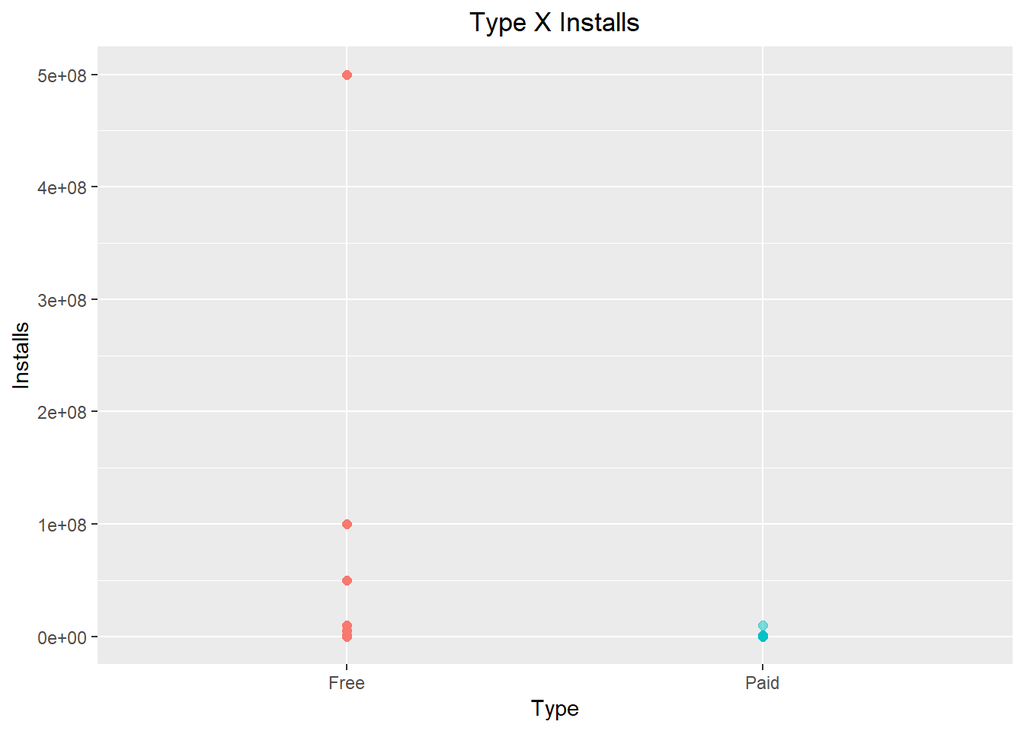

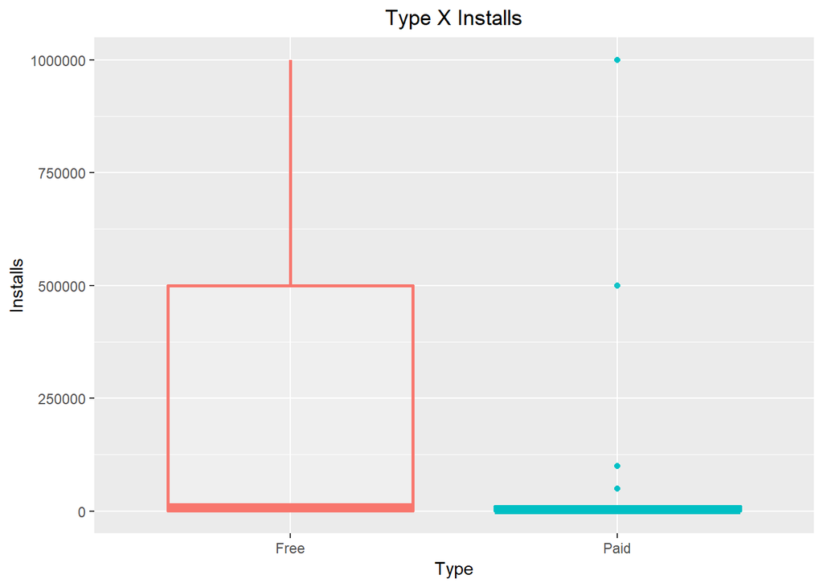

```
## df$Type: 0
## NULL
## --------------------------------------------------------
## df$Type: Free
##      Min.   1st Qu.    Median      Mean   3rd Qu.      Max.      NA's
##         0      5000    100000  10976904   5000000 500000000        58
## --------------------------------------------------------
## df$Type: NaN
##    Min. 1st Qu.  Median    Mean 3rd Qu.    Max.
##       0       0       0       0       0       0
## --------------------------------------------------------
## df$Type: Paid
##     Min.  1st Qu.   Median     Mean  3rd Qu.     Max.
##        0      100     1000    91195    10000 10000000
```

Both plots show that free apps are downloaded more, as the number of installs for paid apps stays at lower values.

The second plot is actually zoomed in on the lower values, limiting the y axis at 1000000.

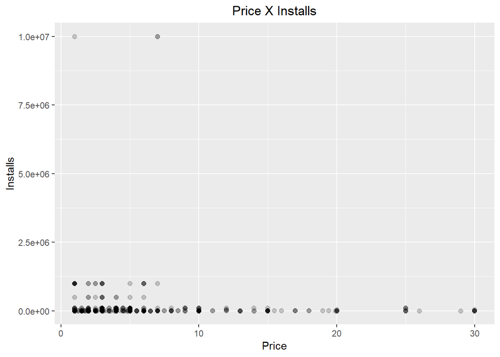

From the paid apps, most apps have a price below 10 dollars. Also, only apps that cost less than around 7 dollars manage to reach a number of installs greater than the lower values, which most apps fall in.

If an app developer does decide to make their app paid, this kind of information could help on princing it properly.

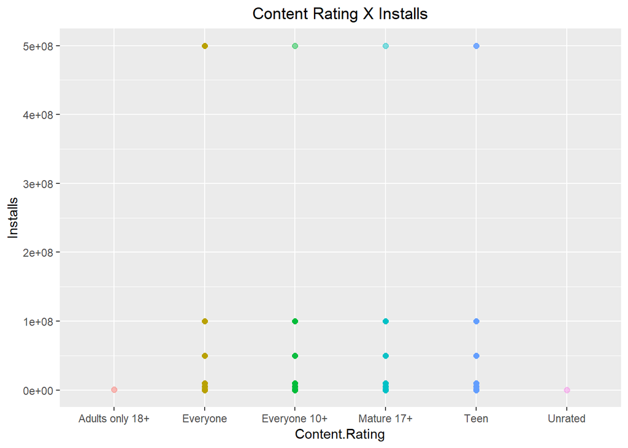

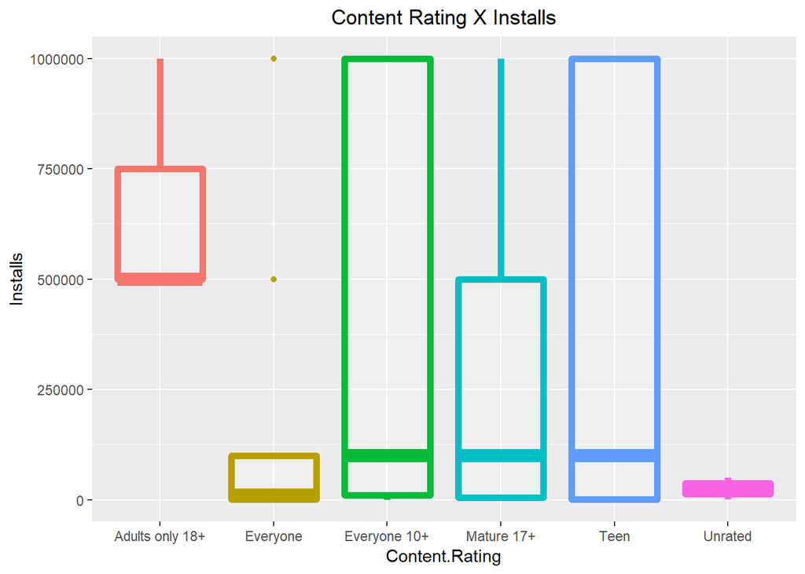

It seems that apps which are rated for adults or unrated aren’t numerous in the dataset, and stay at lower values of installs. In contrast however, all the other categories for content rating do get past the range of lower values for installations, being able to also reach the highest values overall.

The second plot is limiting the y axis at 1000000, and with it we can observe that for lower values, apps rated for adults only have a minimum number of installations higher than the other categories, and thats also true for its median.

In the zoomed in boxplot, one can also see that apps rated for everyone seem to have less installs than most of the other categories, while apps from the content rating categories Everyone 10+, MAture 17+ and Teen seem to have a median close to eachother and reach around the same maximum values too.

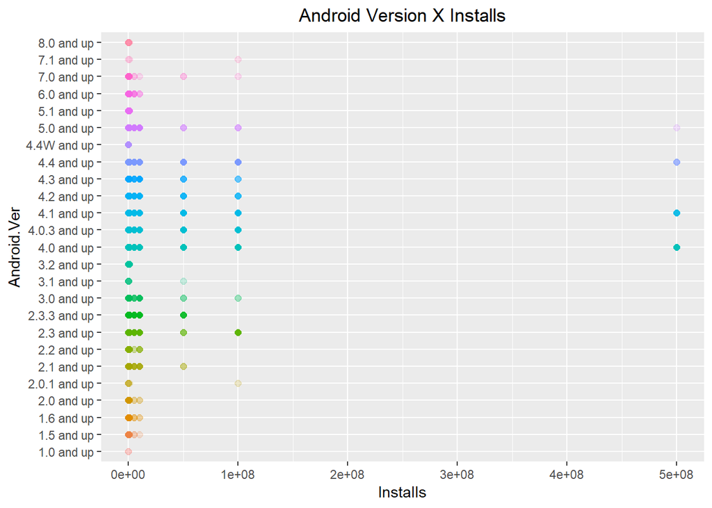

Lastly, there are app installations for apps with minimum requirements for all Android Versions, but for greater numbers of installs, only apps ranging from 2.0.1 to 7.1, with the most downloaded apps being in the versions between 4.0 and 5.0.

## Other variables

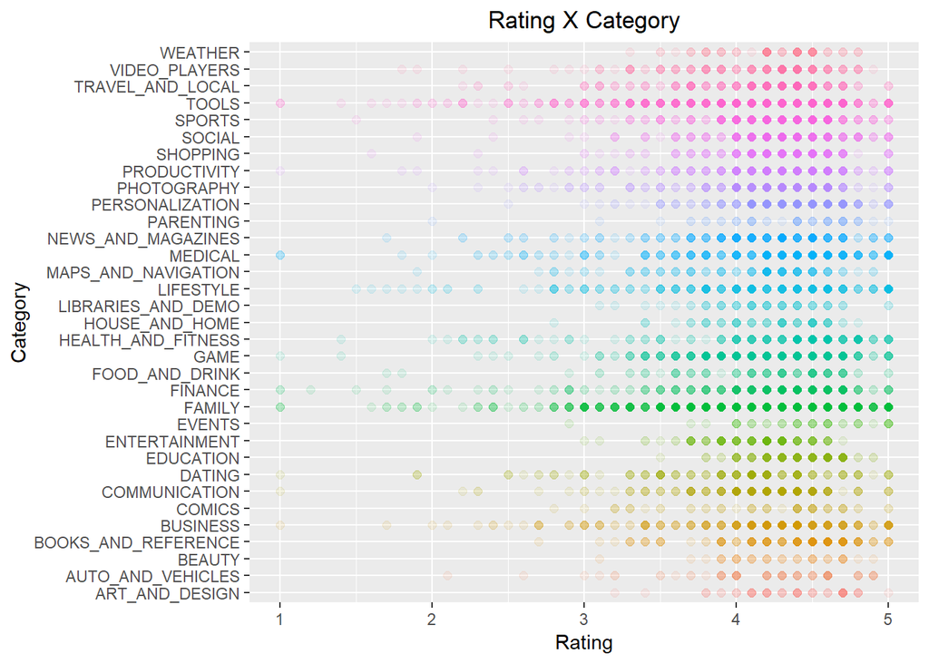

Again, most apps fall in the rating range between 3 and 5, but no category in particular demonstrates having a better overall rating than others. I wonder if the same happens with genre?

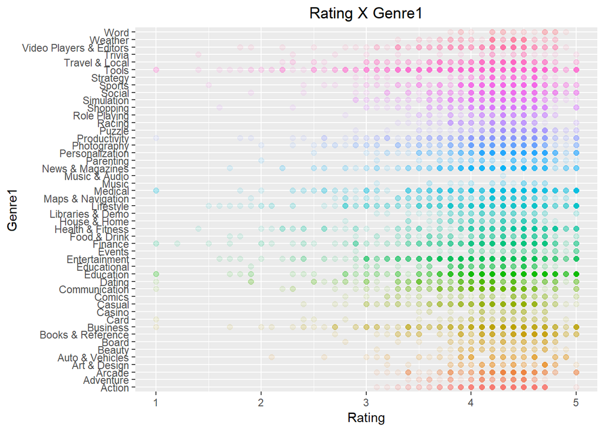

Unsurprisingly, the same does seem to happen when analyzing rating by genres: regardless of genre, they all seem to have their ratings concentrated between 3 and 5.

# Bivariate Analysis

### Talk about some of the relationships you observed in this part of the investigation. How did the feature(s) of interest vary with other features in the dataset?

Only apps with relatively good ratings (greater than or equal 3.5) have higher than average values for number of installations. Of those, only apps with ratings greater than or equal than 4 are in the highest tier of number of installations.

Apps of the genres Video Players and Editors, Action, Casual, Communication, Health and Fitness, News and Magazines, Productivity, Social and Tools are more downloaded.

Similarly, the most favoured categories are: Video Players, Tools, Social, Productivity, News and Magazines, Health and Fitness, Game, Family, Communication.

Both the number of reviews and size of an app did not show to have any correlation with how many installs an app has, which indicates that customers don’t pay much attention to this kind of information.

Only free apps were able top reach higher values of installations than the overall average.

From the paid apps, the higher values of installations were only reached by apps with a price equal or below 7 dollars.

Apps that are unrated, or rated only for adults are the least installed overall.

Apps with a minimum required version ranging from 2.0.1 to 7.1 reach higher values of installs, but only apps with minimum version between 4.0 and 5.0 have the highest value of installs.

### Did you observe any interesting relationships between the other features (not the main feature(s) of interest)?

I analyzed the relationship of ratings with genre and category, and did not really find a interesting relationship between them.

### What was the strongest relationship you found?

Due to almost all variables being originally categorical, especially the main feature of interest, I did not analyze the correlation values between them.

# Multivariate Plots Section

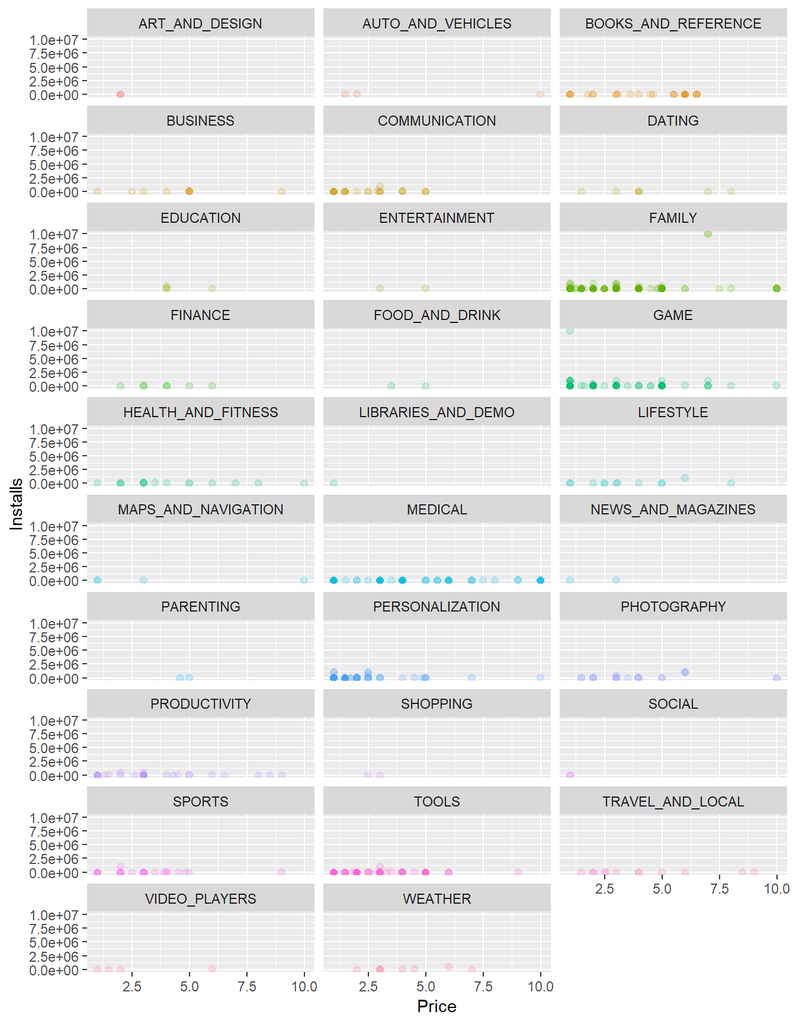

The most downlaoded apps, from the paid ones, were from the categories Game and Family.

Most paid apps, regardless of category, have prices below 5 dollars. Nevertheless, the most downloaded apps from the Family category were more expensive than that.

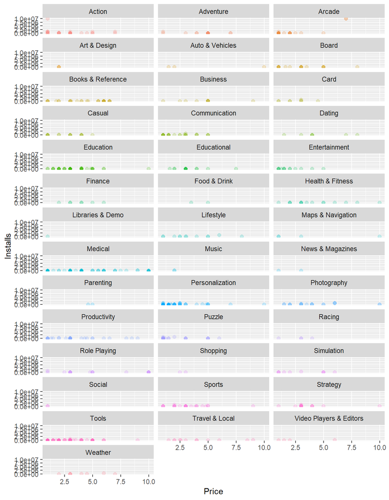

Maybe because there are too many categories, but when the same plot is created but with genre instead, it does not seem to offer any relevant information.

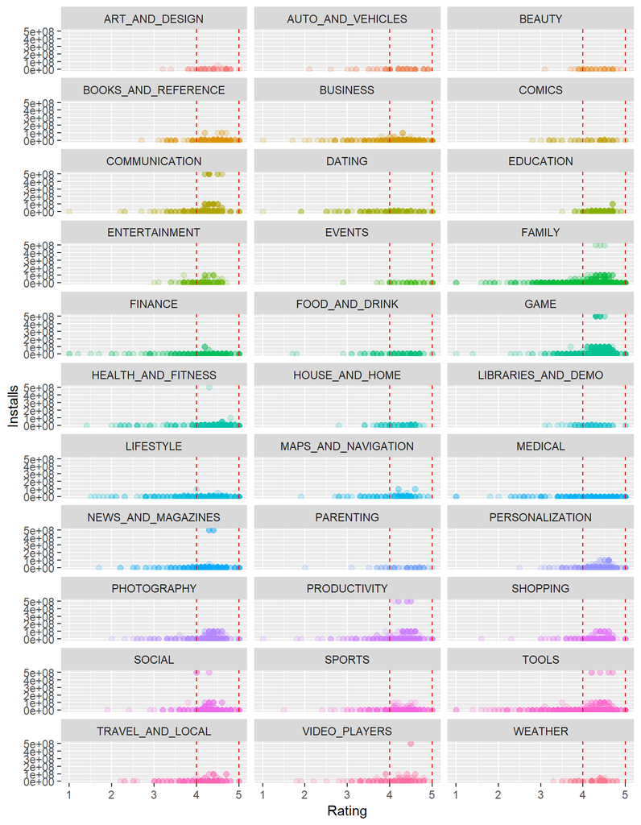

Are the most favoured apps, namely the ones with the highest rating (between 4 and 5) and number of installs, more numerable in any specific category?